# India_REnt

sdc

5/28/2021

```r
library(tidyverse)
library(rvest)
library(broom)
```

# Data

comes from: https://www.kaggle.com/saisaathvik/house-rent-prices-of-metropolitan-cities-in-india A great web scraping project.

## Scraping for Population and GDP pc Data

### City GDPs

Even Though, Cities have huge effects (explains more, as you will see at the end) actually the underlying effect comes from GDP of the city and its population.

To get the gdp per capita and population per city, a little web scraping made from the wikipedia

```r
url <- "https://en.wikipedia.org/wiki/List_of_cities_by_GDP"
wiki_scrape_list <- url %>%
  read_html() %>%
  html_table(fill = T)

wiki_city_df <- wiki_scrape_list[[1]]

colnames(wiki_city_df) <- c("City", "Country", "Region", "GDP_", "Brookings")

sev_city <- wiki_city_df %>%
  filter(City %in% cities) %>%
  rename(GDP = Brookings) %>%
  select(City, GDP) %>%
  separate(GDP, into = c("GDP", "Trash"), sep = "\\[") %>%
  select(-Trash) %>%
  mutate(GDP = as.double(GDP),
         GDP = GDP * 1e9)
sev_city
```

| City | GDP |
| --- | --- |
| Ahmedabad | 7.05e+10 |
| Chennai | 8.26e+10 |
| Delhi | 3.04e+11 |
| Hyderabad | 7.52e+10 |
| Kolkata | 2.54e+11 |
| Mumbai | 3.10e+11 |
| Pune | 6.90e+10 |

Only Bangalore is missing. But it is available at: https://en.wikipedia.org/wiki/List_of_Indian_cities_by_GDP_per_capita

```r
url <- "https://en.wikipedia.org/wiki/List_of_Indian_cities_by_GDP_per_capita"
wiki_top_six_list <- url %>%
  read_html() %>%
  html_table(fill = T)

wiki_top_six_df <- wiki_top_six_list[[1]]
colnames(wiki_top_six_df) <- c("Rank", "City", "State", "GDP_pc", "tr")

top_six <- wiki_top_six_df %>%
  select(City, GDP_pc) %>%
  mutate(GDP_pc = parse_number(GDP_pc))

top_six
```

| City | GDP_pc |
| --- | --- |
| Mumbai | 7830 |
| Delhi | 6390 |
| Chennai | 5870 |
| Hyderabad | 4430 |
| Kolkata | 4420 |
| Bangalore | 3110 |

### City Populations

Since the top_six is in terms of per capita we need population data to get all cities. Note: The years of population and Gdp data come from different years. I assumed there was no demographic changes so the difference of these metropolitians stayed same.

```r
url <- "https://en.wikipedia.org/wiki/List_of_cities_in_India_by_population"
wiki_pop_list <- url %>%
  read_html() %>%
  html_table(fill = T)

wiki_pop_df <- wiki_pop_list[[1]]

colnames(wiki_pop_df) <- c("Rank", "City", "Pop", "Pop01", "State")
```

Now all the cities data is available. The missing value of Bangalore found with average of the ratio. This requires another assumption of the share of the Bangalore did not changed over time.

```r
main_tbl0 <- wiki_pop_df %>%
  filter(City %in% cities) %>%
  left_join(., sev_city) %>%
  left_join(., top_six) %>%
  mutate(Pop = parse_number(Pop),
         GDP2 = GDP_pc * Pop)
average <- main_tbl0 %>%
  filter(City != "Bangalore") %>%
  pull(GDP2) %>%
  summary() %>%
  tidy() %>%
  pull(mean)
Bangalore <- main_tbl0 %>%
  filter(City == "Bangalore") %>%
  pull(GDP2)

Ratio <- Bangalore / average

cities_gdp_pc <- main_tbl0 %>%
  mutate(GDP = if_else(
    City == "Bangalore",
    mean(main_tbl0$GDP, na.rm = T) * Ratio,
    GDP),
    GDP_pc = GDP / Pop
  ) %>%
  select(City, Pop, GDP_pc)

cities_gdp_pc
```

| City | Pop | GDP_pc |
| --- | --- | --- |
| Mumbai | 12442373 | 24914.86 |
| Delhi | 11007835 | 27616.69 |
| Bangalore | 8436675 | 10555.45 |
| Hyderabad | 6809970 | 11042.63 |
| Ahmedabad | 5570585 | 12655.76 |
| Chennai | 4681087 | 17645.47 |
| Kolkata | 4486679 | 56612.03 |
| Pune | 3115431 | 22147.82 |

### Combine All The Cities

And a sample from the data before starting to the analysis

```r
combined <- rbind(Ahmedabad_rent,
      Bangalore_rent,
      Chennai_rent,
      Delhi_rent,
      Hyderabad_rent,
      Kolkata_rent,
      Mumbai_rent,
      Pune_rent)

colnames(combined) <- c("seller", "bedroom", "layout", "property",
                        "locality", "price", "area", "furnish", "bathroom",
                        "City")

analysis_tbl <- combined %>%
  left_join(., cities_gdp_pc) %>%
  mutate(bathroom = as.double(str_remove(bathroom, " bathrooms")),
         furnish = as.factor(str_replace(furnish, "-", "_")),
         layout = as.factor(layout),
         locality = as.factor(locality),
         City = as.factor(City))
analysis_tbl %>% sample_n(10)
```

| seller | bedroom | layout | property | locality | price | area | furnish | bathroom | City | Pop | GDP_pc |
| --- | --- | --- | --- | --- | --- | --- | --- | --- | --- | --- | --- |
| AGENT | 1 | BHK | Independent Floor | Greater Kailash | 35000.00 | 1250 | Furnished | 1 | Delhi | 11007835 | 27616.69 |
| AGENT | 4 | BHK | Apartment | Bodakdev | 1.10 | 4200 | Furnished | 4 | Ahmedabad | 5570585 | 12655.76 |
| AGENT | 1 | BHK | Apartment | Chembur | 29500.00 | 656 | Unfurnished | 1 | Mumbai | 12442373 | 24914.86 |
| OWNER | 2 | BHK | Apartment | Gagan Vihar | 8000.00 | 965 | Semi_Furnished | 2 | Delhi | 11007835 | 27616.69 |
| AGENT | 4 | BHK | Apartment | Sector 19 Dwarka | 40000.00 | 2000 | Semi_Furnished | 3 | Delhi | 11007835 | 27616.69 |
| AGENT | 1 | BHK | Independent House | Rajinder Nagar | 30000.00 | 900 | Furnished | 1 | Delhi | 11007835 | 27616.69 |
| AGENT | 2 | BHK | Apartment | Wagholi | 12000.00 | 951 | Unfurnished | 2 | Pune | 3115431 | 22147.82 |
| OWNER | 1 | BHK | Apartment | Chakan | 5500.00 | 630 | Unfurnished | 1 | Pune | 3115431 | 22147.82 |
| AGENT | 3 | BHK | Apartment | Thaltej | 20000.00 | 1500 | Furnished | 3 | Ahmedabad | 5570585 | 12655.76 |
| AGENT | 4 | BHK | Independent Floor | Navjeevan Vihar | 2.74 | 5412 | Unfurnished | 4 | Delhi | 11007835 | 27616.69 |

## Analysis

There are two types of missing value: - All obs are missing except the city - Only bathroom missing

First ones can’t be recovered but second one’s, bathroom values, can be guessed

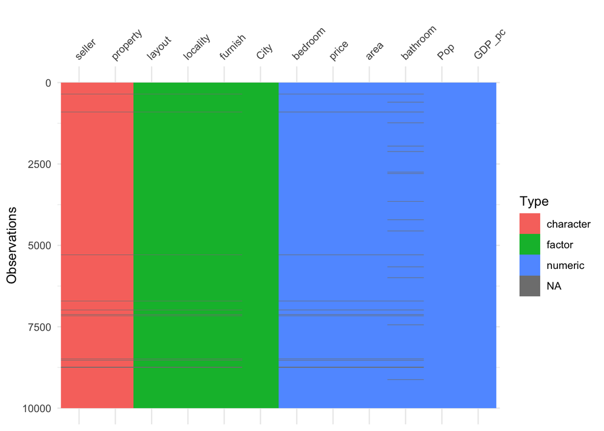

```r
analysis_tbl %>%
  sample_n(10000) %>%
  visdat::vis_dat()
```

### Same Obs with Only the City Var.

First type of NAs have been seen in three cities:

It is important to note these cities since only three cities are containing these missing values.

```r
analysis_tbl %>%
  filter(is.na(furnish)) %>%
  count(City)
```

| City | n |
| --- | --- |
| Chennai | 483 |
| Delhi | 500 |
| Mumbai | 78 |

Excluding 1061 observations

```r
analysis_tbl1 <- analysis_tbl %>%
  filter(!is.na(furnish))
```

Before dealing with the missing bathroom values, there is an important issue in the data.

### Incorrect Price Values

There are some obs between 0-30? Other than that price has right-skewed distribution since there may be extravagant houses

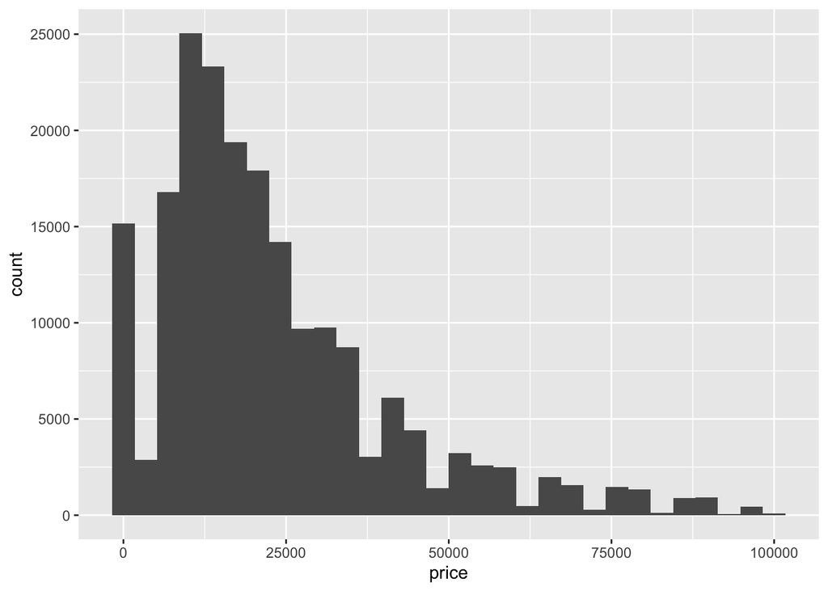

```r
analysis_tbl1 %>%
  ggplot(aes(price)) +
  geom_histogram()
```

Logarithm transformation seems good but ones between 0-30 looks odd! They look like another cluster!

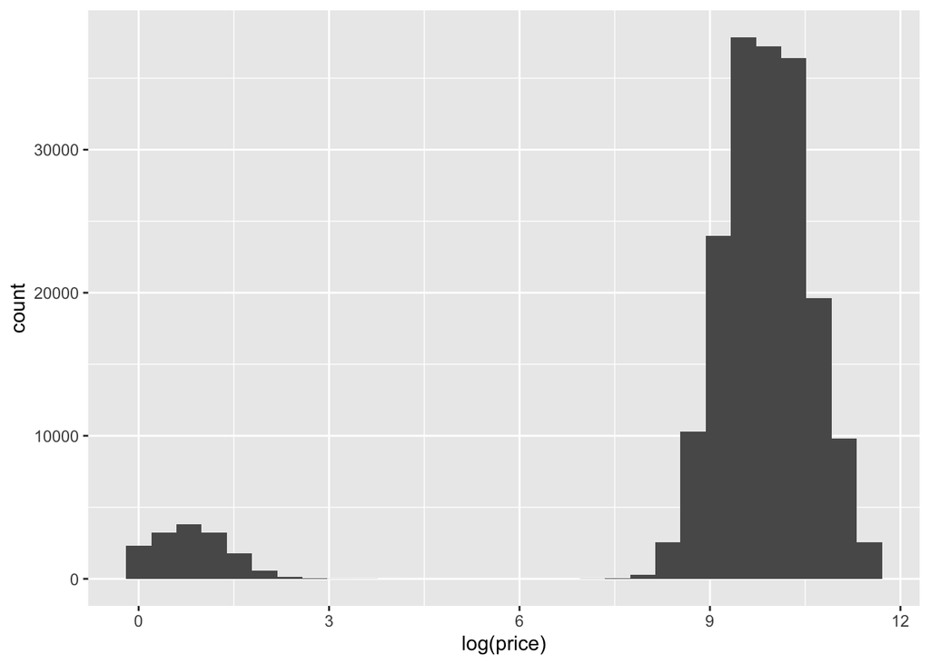

```r
analysis_tbl1 %>%
  ggplot(aes(log(price))) +
  geom_histogram()
```

These are actually good houses. Huge areas, lots of bathrooms. There is a measurement error.

```r
analysis_tbl1 %>%
  filter(price < 100) %>%
  sample_n(20)
```

| seller | bedroom | layout | property | locality | price | area | furnish | bathroom | City | Pop | GDP_pc |
| --- | --- | --- | --- | --- | --- | --- | --- | --- | --- | --- | --- |
| AGENT | 3 | BHK | Apartment | Parel | 2.25 | 2130 | Semi_Furnished | 4 | Mumbai | 12442373 | 24914.86 |
| AGENT | 3 | BHK | Apartment | Powai | 1.10 | 1050 | Furnished | 3 | Mumbai | 12442373 | 24914.86 |
| AGENT | 2 | BHK | Apartment | Bandra West | 1.35 | 800 | Furnished | 2 | Mumbai | 12442373 | 24914.86 |
| AGENT | 3 | BHK | Independent Floor | Hauz Khas | 1.45 | 2351 | Unfurnished | 3 | Delhi | 11007835 | 27616.69 |
| AGENT | 5 | BHK | Villa | Panchsheel Enclave | 5.46 | 8521 | Unfurnished | 5 | Delhi | 11007835 | 27616.69 |
| AGENT | 3 | BHK | Independent Floor | Greater kailash 1 | 2.23 | 2852 | Unfurnished | 3 | Delhi | 11007835 | 27616.69 |
| AGENT | 3 | BHK | Apartment | Ville Parle East | 1.10 | 1366 | Unfurnished | 3 | Mumbai | 12442373 | 24914.86 |
| AGENT | 3 | BHK | Apartment | Kandivali West | 1.50 | 1790 | Furnished | 3 | Mumbai | 12442373 | 24914.86 |
| AGENT | 3 | BHK | Independent Floor | Greater Kailash II | 2.35 | 2852 | Unfurnished | 3 | Delhi | 11007835 | 27616.69 |
| BUILDER | 5 | BHK | Villa | Whitefield Hoskote Road | 2.50 | 7000 | Semi_Furnished | 5 | Bangalore | 8436675 | 10555.45 |

[output cut: 10 more lines]

Yes these might be scraped wrong. Since it just writes 2.5 at the CSVs also.

```r
analysis_tbl1 %>%
  filter(area == 6732)
```

| seller | bedroom | layout | property | locality | price | area | furnish | bathroom | City | Pop | GDP_pc |
| --- | --- | --- | --- | --- | --- | --- | --- | --- | --- | --- | --- |
| OWNER | 10 | BHK | Apartment | Ashram Road | 2.5 | 6732 | Unfurnished | 2 | Ahmedabad | 5570585 | 12655.76 |

At the site it look like this:

https://www.makaan.com/ahmedabad/builder-narayan-chambers-in-ashram-road-13778384/10bhk-2t-6732-sqft-apartment-for-rent

It says 2.5L What does that mean?

https://www.indiamike.com/india/money-issues-and-india-travel-f138/is-200-000-irp-per-month-a-good-salary-in-bangalore-t123164/#post1089587

These guys say that: 2 lacs per month (200,000 INR) means your are going to live a royal life in banglore. Its more than enough in India

But how the area distributed in the dataset?

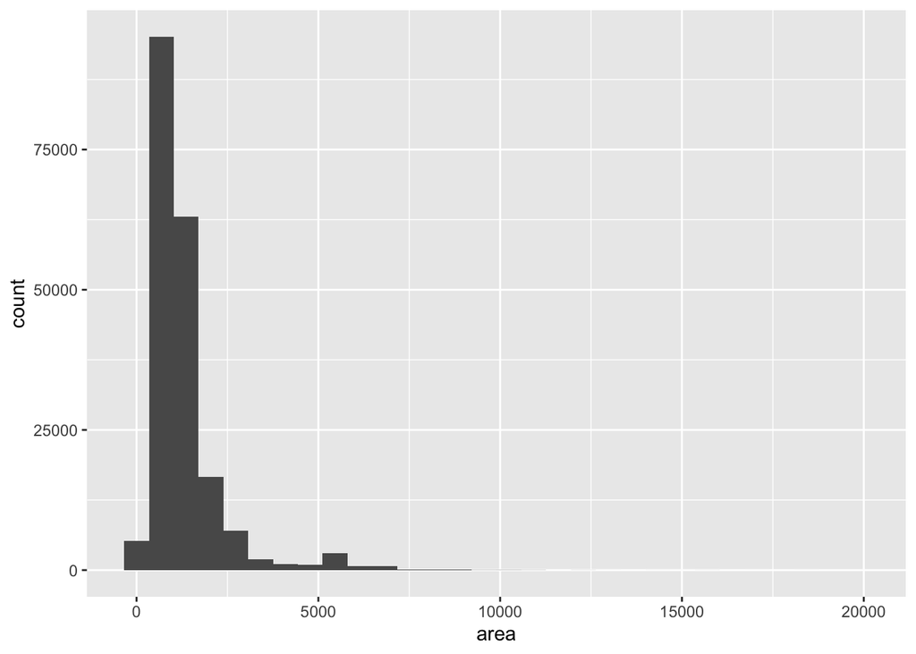

```r
analysis_tbl1 %>%
  ggplot(aes(area)) +
  geom_histogram()
```

Ok it is logical to have this high rents then especially with 6732

Let’s assume for all values price < 100 they must be multiplied with 1e5

```r
analysis_tbl1_2 <- analysis_tbl1 %>%
  mutate(
    price = if_else(price < 100, price * 1e5, price),
    lprice = log(price),
    larea = log(area)
  )
```

These values can be estimated:

```r
analysis_tbl1 %>%
  filter(is.na(bathroom)) %>%
  sample_n(10)
```

[output not shown]

I assume that bathroom number can be explained with area, price, and bedroom

```r
lm_model <- analysis_tbl1 %>%
  filter(!is.na(bathroom)) %>%
  lm(data = .,
     formula = bathroom ~ area + I(area^2) + price + I(price^2) + bedroom + I(bedroom^2))

lm_model %>%
  summary()
```

```
##
## Call:
## lm(formula = bathroom ~ area + I(area^2) + price + I(price^2) +
##     bedroom + I(bedroom^2), data = .)
##
## Residuals:
##     Min      1Q  Median      3Q     Max
## -7.6139 -0.1980  0.0209  0.1611  8.7161
##
## Coefficients:
##                Estimate Std. Error t value Pr(>|t|)
## (Intercept)   4.655e-01  3.313e-03  140.48   <2e-16 ***
## area          4.239e-04  3.690e-06  114.89   <2e-16 ***
## I(area^2)    -3.558e-08  4.580e-10  -77.69   <2e-16 ***
## price         5.930e-07  2.148e-08   27.61   <2e-16 ***
## I(price^2)   -3.091e-13  9.977e-15  -30.99   <2e-16 ***
## bedroom       4.642e-01  3.425e-03  135.52   <2e-16 ***
## I(bedroom^2)  3.136e-02  5.140e-04   61.02   <2e-16 ***
## ---
## Signif. codes:  0 '***' 0.001 '**' 0.01 '*' 0.05 '.' 0.1 ' ' 1
##
## Residual standard error: 0.4213 on 193008 degrees of freedom
## Multiple R-squared:  0.7969, Adjusted R-squared:  0.7969
## F-statistic: 1.262e+05 on 6 and 193008 DF,  p-value: < 2.2e-16
```

```r
estimates <- lm_model %>%
  tidy() %>%
  pull(estimate)
```

Adj. R square is not bad. Let’s implement these to the main table

```r
analysis_tbl2 <- analysis_tbl1 %>%
  mutate(
    bathroom_imputed = if_else(
      is.na(bathroom), 1, 0
    ),
    bathroom = if_else(
      is.na(bathroom),
      estimates[1] + estimates[2] * area + estimates[3] * area^2 +
        estimates[4] * price + estimates[5] * price^2 +
        estimates[6] * bedroom + estimates[7] * bedroom^2,
      bathroom
    ),
    bathroom = round(bathroom, 0)
  )
```

#### How the imputed ones look?

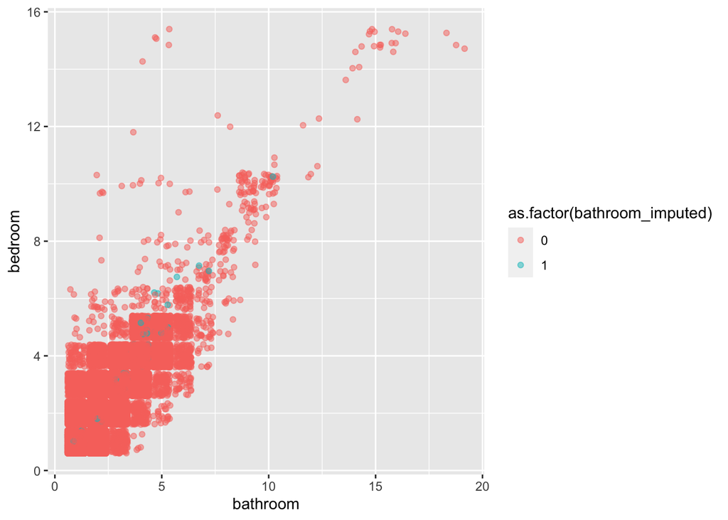

```r
analysis_tbl2 %>%
  ggplot(aes(bathroom, bedroom,color = as.factor(bathroom_imputed))) +
  geom_jitter(alpha = .5)
```

### Understanding The Variables

Again let’s look at again the distribution of the price and the other variables

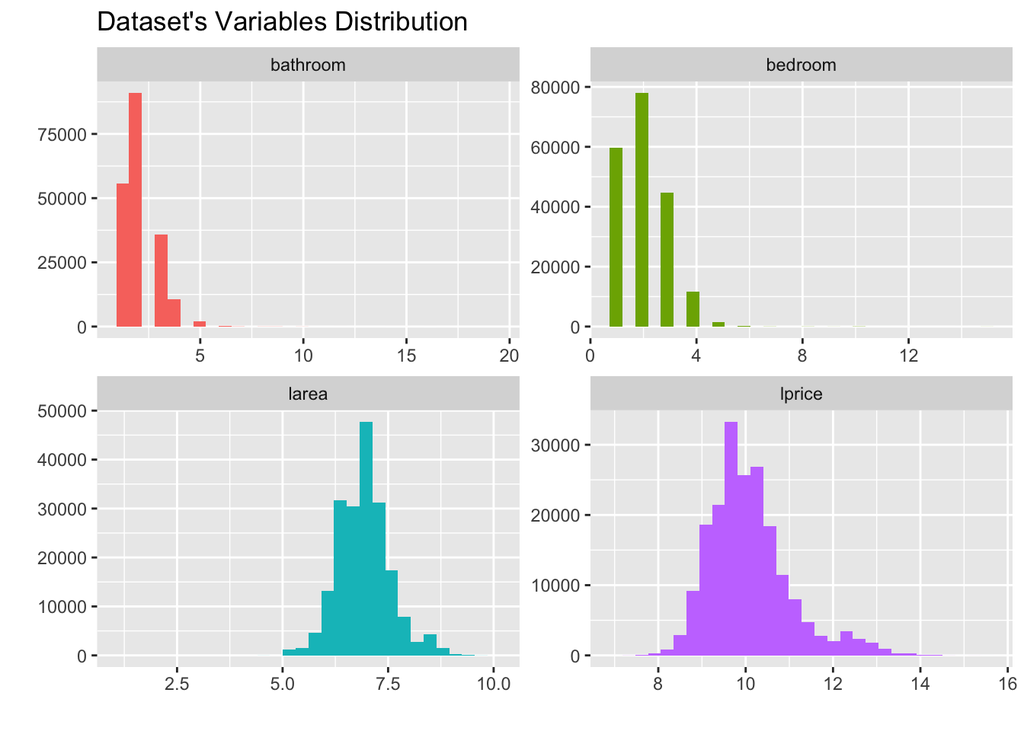

```r
analysis_tbl3 %>%
  mutate(row_no = row_number()) %>%
  pivot_longer(cols = c(bedroom, lprice, larea, bathroom)) %>%
  ggplot(aes(value, fill = as.factor(name))) +
  geom_histogram() +
  facet_wrap(~name, scales = "free", nrow = 2) +
  labs(title = "Dataset's Variables Distribution",
       y = "", x = "") +
  theme(legend.position = "none")
```

### Look to the Categorical Variables

Some localities are very common but also there are lots locality with only 1 observation

```r
analysis_tbl3 %>%
  count(locality) %>%
  arrange(desc(n)) %>%
  head(20)
```

| locality | n |
| --- | --- |
| Thane West | 4518 |
| Chembur | 3665 |
| Andheri East | 3549 |
| Bopal | 2941 |
| Kharghar | 2618 |
| Andheri West | 2403 |
| Bandra West | 2392 |
| Kandivali East | 2255 |
| Powai | 2240 |
| Wagholi | 2169 |

[output cut: 10 more lines]

```r
analysis_tbl3 %>%
  count(locality) %>%
  arrange(desc(n)) %>%
  tail(20)
```

| locality | n |
| --- | --- |
| Wagholi Kesnand Wadegaon Road | 1 |
| wakad | 1 |
| Wakad Chowk Road | 1 |
| Wanawadi Gaon | 1 |
| Weaker Section Colony | 1 |
| West Patel Nagar Road | 1 |
| Westend | 1 |
| Westend DLF Chattarpur Farms | 1 |
| Western Express Highway Malad East | 1 |
| Whitefield Hagadur | 1 |

[output cut: 10 more lines]

Mostly from agent, and the owner

```r
analysis_tbl3 %>%
  count(seller)
```

| seller | n |
| --- | --- |
| AGENT | 155118 |
| BUILDER | 1369 |
| OWNER | 39287 |
| NA | 3 |

BHK: Bedroom Hall Kitchen RK: 1 room that combines bedroom hall and separate kitchen

```r
analysis_tbl3 %>%
  count(layout)
```

| layout | n |
| --- | --- |
| BHK | 185988 |
| RK | 9789 |

```r
analysis_tbl3 %>%
  count(furnish)
```

| furnish | n |
| --- | --- |
| Furnished | 39170 |
| Semi_Furnished | 97042 |
| Unfurnished | 59565 |

```r
analysis_tbl3 %>%
  count(City)
```

| City | n |
| --- | --- |
| Ahmedabad | 18540 |
| Bangalore | 23540 |
| Chennai | 8800 |
| Delhi | 33000 |
| Hyderabad | 10757 |
| Kolkata | 9900 |
| Mumbai | 68440 |
| Pune | 22800 |

```r
analysis_tbl3 %>%
  count(property)
```

| property | n |
| --- | --- |
| Apartment | 141855 |
| Independent Floor | 27696 |
| Independent House | 13125 |
| Penthouse | 156 |
| Studio Apartment | 9789 |
| Villa | 3156 |

## Linear Regression

### Selecting Base Level’s of The Categorical Variables

```r
analysis_tbl4 <- analysis_tbl3 %>%
  mutate(
    seller = fct_relevel(as.factor(seller), "AGENT"),
    City = fct_relevel(City, "Mumbai"),
    furnish = fct_relevel(furnish, "Semi_Furnished"),
    property = fct_relevel(property, "Apartment"),
    lPop = log(Pop),
    lGdp = log(GDP_pc)
  )
```

```r
linear_reg <- analysis_tbl4 %>%
  lm(data = .,
     formula = lprice ~ seller + bedroom + I(bedroom^2) +
       property + furnish + larea + City + bathroom + I(bathroom^2))
```

```r
linear_reg %>% summary()
```

```
##
## Call:
## lm(formula = lprice ~ seller + bedroom + I(bedroom^2) + property +
##     furnish + larea + City + bathroom + I(bathroom^2), data = .)
##
## Residuals:
##     Min      1Q  Median      3Q     Max
## -3.6753 -0.2945 -0.0024  0.2842  5.3930
##
## Coefficients:
##                             Estimate Std. Error  t value Pr(>|t|)
## (Intercept)                3.9432272  0.0230282  171.234  < 2e-16 ***
## sellerBUILDER             -0.3017095  0.0131976  -22.861  < 2e-16 ***
## sellerOWNER               -0.1906518  0.0031039  -61.423  < 2e-16 ***
## bedroom                    0.0337603  0.0051785    6.519 7.08e-11 ***
## I(bedroom^2)               0.0060930  0.0008291    7.349 2.00e-13 ***
## propertyIndependent Floor  0.1169609  0.0041353   28.283  < 2e-16 ***
## propertyIndependent House -0.0102893  0.0048069   -2.141   0.0323 *
## propertyPenthouse          0.5508902  0.0389292   14.151  < 2e-16 ***
## propertyStudio Apartment   0.1252774  0.0056438   22.198  < 2e-16 ***
## propertyVilla              0.2241389  0.0091616   24.465  < 2e-16 ***
## furnishFurnished           0.2886730  0.0029751   97.030  < 2e-16 ***
## furnishUnfurnished        -0.0195881  0.0026594   -7.365 1.77e-13 ***
## larea                      0.8713751  0.0040169  216.930  < 2e-16 ***
## CityAhmedabad             -1.0422652  0.0042003 -248.138  < 2e-16 ***
## CityBangalore             -0.5789335  0.0041645 -139.017  < 2e-16 ***
## CityChennai               -0.6394569  0.0058766 -108.814  < 2e-16 ***
## CityDelhi                 -0.2720454  0.0042652  -63.783  < 2e-16 ***
## CityHyderabad             -0.7597716  0.0052434 -144.901  < 2e-16 ***
## CityKolkata               -0.7403331  0.0054106 -136.829  < 2e-16 ***
## CityPune                  -0.5731232  0.0037787 -151.672  < 2e-16 ***
## bathroom                   0.1788099  0.0050641   35.309  < 2e-16 ***
## I(bathroom^2)             -0.0033849  0.0008199   -4.128 3.66e-05 ***
## ---
## Signif. codes:  0 '***' 0.001 '**' 0.01 '*' 0.05 '.' 0.1 ' ' 1
##
## Residual standard error: 0.4843 on 195752 degrees of freedom
##   (3 observations deleted due to missingness)
## Multiple R-squared:  0.727,  Adjusted R-squared:  0.727
## F-statistic: 2.483e+04 on 21 and 195752 DF,  p-value: < 2.2e-16
```

### Reporting Without Categorical Variables

```r
linear_reg %>%
  stargazer::stargazer(type = "text", keep = c("area", "bedroom", "bathroom"))
```

```
##
## ===================================================
##                           Dependent variable:
##                     -------------------------------
##                                 lprice
## ---------------------------------------------------
## bedroom                        0.034***
##                                 (0.005)
##
## I(bedroom2)                    0.006***
##                                 (0.001)
##
## larea                          0.871***
##                                 (0.004)
##
## bathroom                       0.179***
##                                 (0.005)
##
## I(bathroom2)                   -0.003***
##                                 (0.001)
##
## ---------------------------------------------------
## Observations                    195,774
## R2                               0.727
## Adjusted R2                      0.727
## Residual Std. Error       0.484 (df = 195752)
## F Statistic         24,827.060*** (df = 21; 195752)
## ===================================================
## Note:                   *p<0.1; **p<0.05; ***p<0.01
```

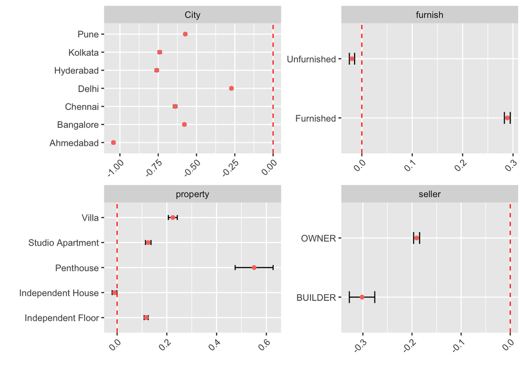

```r
linear_reg %>%
  tidy(conf.int = T) %>%
  select(term, estimate, conf.low, conf.high) %>%
  mutate(categorical = case_when(
    str_detect(term, "seller") ~ "seller",
    str_detect(term, "property") ~ "property",
    str_detect(term, "furnish") ~ "furnish",
    str_detect(term, "City") ~ "City",
    TRUE ~ "numerical"),
    term = str_remove(term, "seller"),
    term = str_remove(term, "property"),
    term = str_remove(term, "City"),
    term = str_remove(term, "furnish"),
  ) %>%
  filter(!categorical == "numerical") %>%
  ggplot() +
  geom_errorbar(aes(x = term, ymin = conf.low, ymax = conf.high, width = .2)) +
  geom_point(aes(x = term, y = estimate, color = "red")) +
  facet_wrap(~ categorical, scales = "free") +
  geom_hline(yintercept = 0, color = "red", linetype = 2) +
  labs(y = "", x = "") +
  theme(axis.text.x = element_text(angle = 45, vjust = 1, hjust=1),
        legend.position = "none") +
  coord_flip()
```

### Instead of City Variables…

One may argue that Mumbai is the largest city and the effect comes from its largeness. Then let’ change the model

```r
linear_reg2 <- analysis_tbl4 %>%
  lm(data = .,
     formula = lprice ~ seller + bedroom + I(bedroom^2) +
       property + furnish + larea + bathroom + I(bathroom^2)+
       lPop + lGdp)
```

```r
linear_reg2 %>%
  stargazer::stargazer(type = "text", keep = c("area", "bedroom", "bathroom", "Pop", "Gdp", "Constant"))
```

```
##
## ===================================================
##                           Dependent variable:
##                     -------------------------------
##                                 lprice
## ---------------------------------------------------
## bedroom                        -0.059***
##                                 (0.005)
##
## I(bedroom2)                    0.012***
##                                 (0.001)
##
## larea                          0.842***
##                                 (0.004)
##
## bathroom                       0.239***
##                                 (0.005)
##
## I(bathroom2)                   -0.007***
##                                 (0.001)
##
## lPop                           0.511***
##                                 (0.003)
##
## lGdp                           0.322***
##                                 (0.003)
##
## Constant                       -7.487***
##                                 (0.056)
##
## ---------------------------------------------------
## Observations                    195,774
## R2                               0.694
## Adjusted R2                      0.694
## Residual Std. Error       0.513 (df = 195757)
## F Statistic         27,739.590*** (df = 16; 195757)
## ===================================================
## Note:                   *p<0.1; **p<0.05; ***p<0.01
```